# Project 3: Bayesian modeling of hurricane trajectories

# Hurricane Data

hurricane356.csv collected the track data of 356 hurricanes in the North Atlantic area since 1989. For all the storms, their location (longitude & latitude) and maximum wind speed were recorded every 6 hours. The data includes the following variables

1. **ID**: ID of the hurricanes
2. **Season**: In which the hurricane occurred
3. **Month**: In which the hurricane occurred
4. **Nature**: Nature of the hurricane
- ET: Extra Tropical
- DS: Disturbance
- NR: Not Rated
- SS: Sub Tropical
- TS: Tropical Storm
5. **time**: dates and time of the record
6. **Latitude** and **Longitude**: The location of a hurricane check point
7. **Wind.kt** Maximum wind speed (in Knot) at each check point

## Load and explore the hurricane data through visulaizations

```r
library(ggplot2)
# dt= read.csv("/cloud/project/hurrican356.csv")
dt= read.csv("./hurrican356.csv")
ggplot(data=dt, aes(x = Longitude, y = Latitude)) +
  stat_summary_2d(data = dt, aes(x = Longitude, y = Latitude, z = dt$Wind.kt), fun = median, binwidth = c(1, 1), show.legend = TRUE)
library(data.table)
dt <- as.data.table(dt)
summary(dt)
```

[output not shown]

Overlay the hurricane data in the world map

```r
library(maps)
map <- ggplot(data = dt, aes(x = Longitude, y = Latitude)) +
  geom_polygon(data = map_data(map = 'world'), aes(x = long, y = lat, group = group))
map +
  stat_summary_2d(data = dt, aes(x = Longitude, y = Latitude, z = dt$Wind.kt), fun = median, binwidth = c(1, 1), show.legend = TRUE, alpha = 0.75) +
  ggtitle(paste0("Atlantic Windstorm mean knot"))
```

[output not shown]

Additional Plots

```r
map <- ggplot(dt, aes(x = Longitude, y = Latitude, group = ID)) +
  geom_polygon(data = map_data("world"),
               aes(x = long, y = lat, group = group),
               fill = "gray25", colour = "gray10", size = 0.2) +
  geom_path(data = dt, aes(group = ID, colour = Wind.kt), size = 0.5) +
  xlim(-138, -20) + ylim(3, 55) +
  labs(x = "", y = "", colour = "Wind \n(knots)") +
  theme(panel.background = element_rect(fill = "gray10", colour = "gray30"),
        axis.text.x = element_blank(), axis.text.y = element_blank(),
        axis.ticks = element_blank(), panel.grid.major = element_blank(),
        panel.grid.minor = element_blank())

seasonrange <- paste(range(dt[, "Season"]), collapse=" - ")

map + ggtitle(paste("Atlantic named Windstorm Trajectories (",
                     seasonrange, ")\n"))
```

[output not shown]

Show hurricane tracks by month

```r
mapMonth <- map + facet_wrap(~ Month) +
  ggtitle(paste("Atlantic named Windstorm Trajectories by Month (",
                 seasonrange, ")\n"))
mapMonth
```

[output not shown]

# A Hierarchical Bayesian model for hurricane trajectories.

Climate researchers are interested in modeling the hurricane trajectories to forecast the wind speed. Let $t$ be time (in hours) since a hurricane began, and For each hurricane $i$, we denote $Y_{i}(t)$ be the wind speed of the $i$th hurricane at time $t$. The following Bayesian model was suggested.

$$Y_{i}(t+6) =\beta_{0,i}+x_{i,1}\beta_{1,i} +
x_{i,2} \beta_{2,i} + x_{i,3}\beta_{3,i} +\beta_{4,i}Y_{i}(t) +\beta_{5,i}\Delta_{i,1}(t)+ \beta_{6,i}\Delta_{i,2}(t)+ +\beta_{7,i}\Delta_{i,3} + \epsilon_{i}(t)$$

where $x_{i,1}$ is the month of year when the hurricane started, $x_{i,2}$ is the calendar year of the hurricane, and $x_{i,3}$ is the type of hurricane, $\Delta_{i,1}(t)$, $\Delta_{i,2}(t)$ and $\Delta_{i,3}(t)$ is the change of latitude longitude, and wind speed between $t-6$ and $t$, and $\epsilon_{i,t}$ follows a normal distributions with mean zero and variance $\sigma^2$, independent across $t$.

In the model, $\boldsymbol{\beta}_{i} = (\beta_{0,i},\beta_{1,i},...,\beta_{7,i})$ are the random coefficients associated the $i$th hurricane, we assume that

$$\boldsymbol{\beta}_{i} \sim N(\boldsymbol{\beta}, \boldsymbol{\Sigma})$$
follows a multivariate normal distributions with mean $\boldsymbol{\beta}$ and covariance matrix $\Sigma$.

We assume the following non-informative or weak prior distributions for $\sigma^2$, $\boldsymbol{\beta}$ and $\Sigma$.
$$P(\sigma^2) \propto \frac{1}{\sigma^2};\quad P(\boldsymbol{\beta})\propto 1;\quad P(\Sigma^{-1}) \propto
|\Sigma|^{-(d+1)} \exp(-\frac{1}{2}\Sigma^{-1})$$
d is dimension of $\beta$.

## Design a MCMC algorithm to estiamte the posterior distributions of the model parameters, and complete the following tasks:

1. Construct their 95% credibility intervals for $\boldsymbol{\beta}$. What we learn from the models? Is there evidence support that the statement that “the hurricane wind speed has been increasing over years”.
2. How well does this Bayesian model track the individual hurricanes?
3. Write a summary statement of your findings and comment on the proposed Bayesian model.

Need to filter times into the 6 hour intervals: 0:00:00, 6:00:00, 12:00:00, 18:00:00. Some times are at random intervals but we have no 6 hours ahead or before so we ignore those cases.

The chain plots of parameters are shown below. Since the accept rate decrease after 1000 iterations, to make transition more efficient, the step size for random walk during first 1000 iterations is set to be different from the second half iterations. Accept rate is 433/2000=0.2165.

[figure not shown]

[figure not shown]

[figure not shown]

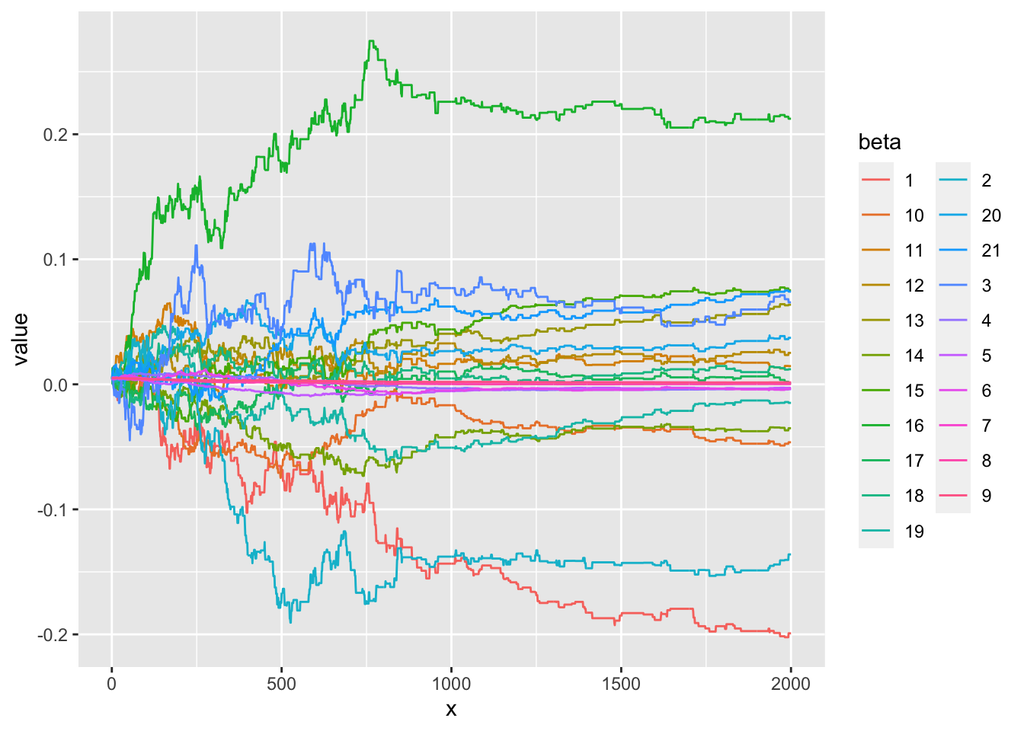

```r
beta_plot
```

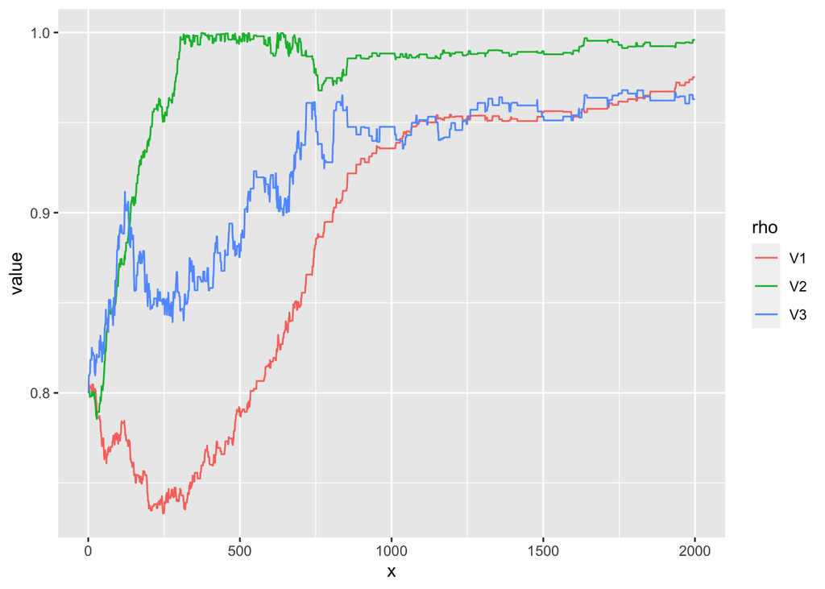

```r
rho_plot
```

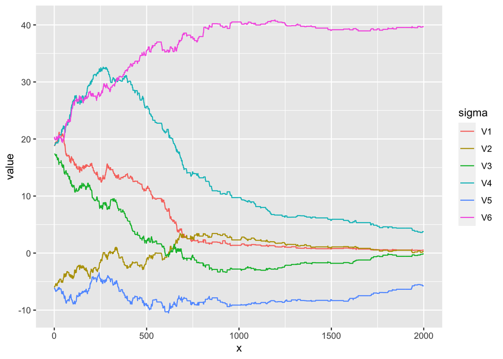

```r
sigma_plot
```

```r
rbind(hat_sigma, ci_sigma)
```

```
##                [,1]      [,2]      [,3]     [,4]      [,5]     [,6]
## hat_sigma 0.6455821 0.6629101 -0.921746 4.892385 -7.085709 39.28929
## 2.5%      0.4825708 0.1302305 -1.804306 3.687700 -8.432473 38.95065
## 97.5%     0.8846660 1.1426207 -0.217086 5.925075 -5.516103 39.73685
```

```r
rbind(hat_rho, ci_rho)
```

```
##              [,1]      [,2]      [,3]
## hat_rho 0.9619010 0.9924871 0.9610554
## 2.5%    0.9532812 0.9879111 0.9512209
## 97.5%   0.9739338 0.9960140 0.9679734
```

```r
rbind(hat_beta, ci_beta)
```

```
##                [,1]       [,2]       [,3]         [,4]         [,5]
## hat_beta -0.1903867 -0.1466539 0.05629307 -0.004002245 -0.003166825
## 2.5%     -0.2015021 -0.1532179 0.04685490 -0.004449642 -0.003539323
## 97.5%    -0.1795303 -0.1404386 0.07119481 -0.003428897 -0.002769387
##                  [,6]        [,7]         [,8]        [,9]       [,10]
## hat_beta -0.003754458 0.001457771 0.0001657076 0.001513396 -0.04148566
## 2.5%     -0.004470306 0.001293552 0.0001194620 0.001445747 -0.04897200
## 97.5%    -0.002471790 0.001611638 0.0002266656 0.001619098 -0.03451818
##               [,11]      [,12]      [,13]       [,14]      [,15]     [,16]
## hat_beta 0.01866644 0.02228782 0.05379715 -0.03534424 0.07331530 0.2127448
## 2.5%     0.01268133 0.01667444 0.04942130 -0.03750112 0.06976071 0.2052810
## 97.5%    0.02401545 0.02767650 0.06408943 -0.03246310 0.07747594 0.2209324
##                [,17]       [,18]       [,19]      [,20]      [,21]
## hat_beta 0.005366264 0.011285070 -0.01836762 0.03162534 0.06589386
## 2.5%     0.001986722 0.008733209 -0.02631055 0.02644778 0.05743969
## 97.5%    0.008616205 0.014633355 -0.01294565 0.03857131 0.07415573
```